# ST1131 Introduction to Statistics and Statistical Computing

## Tutorial 8

```python
# Verify the notebook is using venv-st1131
# You should see either \venv-st1131\Scripts\python.exe or /venv-st1131/bin/python
import sys
from pathlib import Path
print(Path(*Path(sys.executable).parts[-3:]))
```

```
venv-st1131v2\Scripts\python.exe
```

```python
# Verify required packages
import numpy as np
import pandas as pd
import matplotlib.pyplot as plt
from scipy import stats

print("Everything works!")
```

```
Everything works!
```

Some important functions we will use are:

- `stats.ttest_1samp(a,popmean,alternative)` gives the $t$-statistic of a 1 sample $t$-test, where `popmean` is the expected value in the null hypothesis $H_0$, and `alternative` defines the alternative hypothesis $H_1$.
- `stats.norm.cdf()` gives $P(Z \le z)$ for $Z \sim N(0,1)$.
- `stats.norm.sf()` gives $P(Z > z)$ for $Z \sim N(0,1)$.

### Question 1

Recent research suggests that dogs may be helpful in detecting when a person has cancer. Six dogs of varying breeds were trained to distinguish a patient with bladder cancer by smelling certain compounds in the patient's urine. The dogs were trained to indicate which among several specimens was from the bladder cancer patient by lying beside it.

Each of the six dogs was tested with 9 trials. In each trial, one urine sample from a bladder cancer patient was randomly placed among six control urine samples. In the total of 54 trials with the six dogs, the dogs made the correct selection 22 times.

Let $p$ denote the probability that a dog makes the correct selection on a given trial. Perform a test, at 5% significance level, to test if the dog's ability to detect the correct urine specimen is better than random guessing.

(a) State the assumptions and hypotheses of this test.

**Assumptions**:

- The variable is categorical (correct/incorrect selection)
- The data were obtained using randomisation.
- $np_0\left(1-p_0\right) = 54\left(\frac{1}{7}\right)\left(\frac{6}{7}\right) = 6.61 > 5$. The sample size $n=54$ is large enough.

**Hypotheses**: For each trial, there are seven samples, one from a bladder cancer patient and six from control samples. The probability of randomly guessing correctly is $\frac{1}{7}$.

Hence, the hypotheses are: $$ H_0: p = \frac{1}{7} \quad \text{vs} \quad H_1: p > \frac{1}{7} $$

(b) Derive the test statistic and the null distribution of the test. Hence, what is the conclusion in the context of this study?

```python
n, phat, p0 = 54, 22/54, 1/7
z_stat = (phat - p0)/np.sqrt((p0*(1-p0))/n)
p_val = stats.norm.sf(z_stat)
print(f"The test statistic for this test is Z = {z_stat:.3f}")
print(f"The p-value for this test is {p_val}")
```

```
The test statistic for this test is Z = 5.556
The p-value for this test is 1.3836508957768791e-08
```

Test statistic is $$ Z = \frac{\hat{p} - p_0}{\sqrt{\frac{p_0\left(1-p_0\right)}{n}}} $$ where $\hat{p} = \frac{22}{54}$, $n=54$, $p_0 = \frac{1}{7}$.

Test statistic is $Z = 5.56$ and the null distribution is $Z \sim N\left(0,1\right)$.

This is a one-sided test, hence $p$-value is $P(Z > 5.56) = 1.38 \times 10^{-8}$. Since $p$-value of the test is extremely small, we conclude that data provide very strong evidence against $H_0$, supporting $H_1$. That means that the data strongly suggest that the dogs' selections are better than random guessing.

(c) Interpret the $p$-value in the context of this study.

The $p$-value of $1.38 \times 10^{-8}$ is the probability of the test statistic being at least $5.56$ given that the null hypothesis $H_0: p = \frac{1}{7}$ is true. If the dogs were only guessing, the probability (through normal approximation) of getting 22 or more correct out of 54 is about $1.38 \times 10^{-8}$.

**Note:** Generally, $p$-value is the probability that "the test statistic receives the value as observed or more extreme, given $H_0$ is true". The definition of "extreme" depends on how the hypothesis is being tested.

### Question 2

A survey asked randomly selected university students, “On an average day, about how many hours do you spend on social media?” The responses (variable `hours`) are in `SocialMediaHours.csv`. Let $\mu$ denote the population mean hours of social media use.

(a) Report the sample size, sample mean and sample standard deviation.

```python
data = pd.read_csv("../data/SocialMediaHours.csv")
n = len(data)

# Using numpy
sam_mean = np.mean(data['hours'])
sam_sd = np.std(data['hours'], ddof = 1)
print(f"Sample size = {n}")
print(f"Sample mean = {sam_mean:.3f}")
print(f"Sample standard deviation = {sam_sd:.3f}")

# Using pandas
sam_mean = data['hours'].mean()
sam_sd = data['hours'].std()
print(f"Sample mean = {sam_mean:.3f}")
print(f"Sample standard deviation = {sam_sd:.3f}")
```

```
Sample size = 800
Sample mean = 3.514
Sample standard deviation = 2.410
Sample mean = 3.514
Sample standard deviation = 2.410
```

Sample size is 800, sample mean is 3.514 and sample standard deviation is 2.410

(b) Plot a histogram of `hours`. Comment on whether the sample is normally distributed.

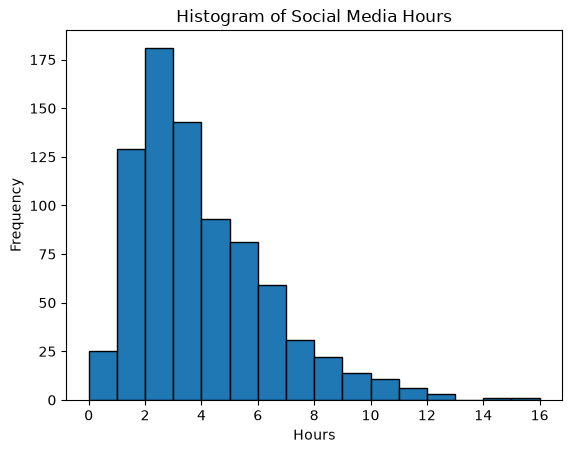

```python
max_val = data['hours'].max()
bins = np.arange(0, max_val + 2, 1)

plt.hist(data, bins=bins, edgecolor = 'black')
plt.title("Histogram of Social Media Hours")
plt.xlabel("Hours")
plt.ylabel("Frequency")
plt.show()
```

The histogram obtained is highly right-skewed, so the data are not normally distributed. Since $n = 800$ is large, the $t$-test is still appropriate.

(c) Suppose that a student wants to test the claim that the number of hours spent on social media is not 3 at 5% significance level. State the hypotheses and assumptions of this test.

Let $\mu$ be the population mean daily hours of social media use among university students.

$$ H_0: \mu = 3 \quad \text{vs} \quad H_1: \mu \neq 3 $$

**Assumptions**:

- The data were obtained from randomisation.
- The variable (number of hours on social media) is quantitative.
- The data distribution of number of hours on social media is not symmetric, but the sample size of 800 is large.

(d) Calculate the test statistic manually (without using `ttest_1samp`).

```python
xbar = sam_mean
mu0 = 3
t_stat = (xbar - mu0)/(sam_sd/np.sqrt(n))
print(f"The t-statistic for this test is {t_stat:.3f}")
```

```
The t-statistic for this test is 6.030
```

The test statistic value is 6.030 and the null distribution of the test statistic is $t_{799}$

(e) Use `ttest_1samp` to perform a test at significance level $\alpha=0.05$ to test whether the number of hours spent on social media differs from 3.

```python
results = stats.ttest_1samp(data['hours'], popmean = 3, alternative='two-sided')
print(f"The t-statistic for this test is {results.statistic:.3f} with p-value {results.pvalue}")
```

```
The t-statistic for this test is 6.030 with p-value 2.504038650529925e-09
```

The test statistic value is 6.030 (identical to that in (d)) and the null distribution of the test statistic is $t_{799}$. The $p$-value is $2.50 \times 10^{-9}$.

Since $p$-value $< 0.05$, we reject $H_0$ and conclude that the data provide strong evidence against $H_0$, and that at 5% significance level, the number of hours spent on social media differs from 3 hours.

(f) Verify the conclusion from part (e) by constructing and interpreting the 95% confidence interval.

```python
se = sam_sd/np.sqrt(n)
sam_t = stats.t.ppf(0.975, df= n-1)
moe = se*sam_t
print(f"95% CI: ({sam_mean - moe:.4f}, {sam_mean + moe:.4f})")

ci = results.confidence_interval(0.95)
print(f"95% CI: ({ci.low:.4f}, {ci.high:.4f})")
```

```
95% CI: (3.3465, 3.6810)
95% CI: (3.3465, 3.6810)
```

Since the confidence interval (3.35, 3.68) does not contain the null value 3, this is consistent with the decision from the test to reject $H_0$. We are 95% confident that the population mean daily social media use is between 3.35 and 3.68 hours.

### Question 3

Management claims that the mean income of all senior-level assembly line workers in a large company equals $500 per week. An employee decides to test this claim, believing that it is actually different from $500. He collected a random sample of 50 employees and recorded their income in a file named `week_salary.csv`.

Use Python to answer the following questions.

(a) Conduct a significance test of whether the population mean income equals $500 per week, including all assumptions, hypotheses, test statistic and $p$-value. Interpret the result in context.

**Assumptions**:

- Data obtained from randomisation
- Variable (salary) is quantitative.
- The sample size $n = 50$ is large, and the histogram is roughly symmetric with no extreme outliers.

**Hypotheses**: $$ H_0: \mu = 500 \quad \text{vs} \quad H_1: \mu \neq 500 $$ where $\mu$ is the average income per week of the senior-level assembly line workers in the whole company (population mean).

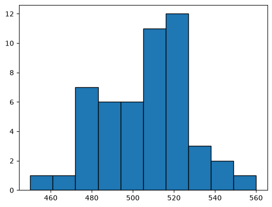

```
The t-statistic for this test is 2.079 with p-value 0.04284394365420244
```

```python
salary = pd.read_csv("../data/week_salary.csv")
plt.hist(salary['x'], edgecolor = 'black')
plt.show()

results = stats.ttest_1samp(salary['x'], popmean=500)
print(f"The t-statistic for this test is {results.statistic:.3f} with p-value {results.pvalue}")
```

**Test statistic and $p$-value**: $$ t = \frac{\bar{X} - \mu_0}{\frac{s}{\sqrt{n}}} = 2.08 $$

The null distribution is $t_{49}$, and $p$-value is 0.0428.

**Conclusion**: Since the $p$-value of 0.0428 is less than 0.05, we reject $H_0$. At the 5% significance level, there is evidence that the mean weekly income of all senior-level assembly line workers differs from $500.

(b) Based on your answer in (a), for which confidence levels would the confidence interval contain 500?

- 90%
- 95%
- 99%

For the confidence interval to contain 500, the null hypothesis $H_0: \mu = 500$ is not rejected. This means that the $p$-value is more than the significance level.

$p = 0.0428$ is below 0.10 and 0.05, so $H_0$ is rejected at those levels and the 90% and 95% intervals exclude 500. It is above 0.01, so the 99% interval contains 500.

Hence, only the 99% confidence interval would contain 500.

(c) In the context of this study, what is a Type I error? What is the probability of it occurring?

A Type I error occurs when we conclude that the mean salary is not $500, when it is in fact true that the mean salary is $500.

The probability of it occurring is equal to the significance level, $\alpha = 0.05$.

(d) In the context of this study, what is a Type II error?

A Type II error occurs when we do not reject $H_0$ when in fact the mean salary is not $500.

### Question 4

A company shows users a new promotional banner in its app. An old banner had a 12% click-through rate. The company wants to test whether the new banner does better. The results are presented in `AppClicks.csv`, a dataset containing 4 variables.

(a) Perform a test to see if the new banner does better than the old banner at 5% significance level, clearly defining assumptions (if any) and the hypotheses.

**Assumptions**:

- Data obtained from randomisation
- Variable (whether user clicked banner or not) is categorical.
- $np_0(1-p_0) = 600(0.12)(1-0.12) = 63.36 > 5$. Sample size $n=600$ is large enough.

**Hypotheses**: $$ H_0: p = 0.12 \quad \text{vs} \quad H_1: p > 0.12 $$ where $p$ is the proportion of all users who would click the new banner (population proportion).

```python
app = pd.read_csv("../data/AppClicks.csv")
n = len(app)
count = app['clicked'].sum()
p0 = 0.12
p_hat = count/n
z_stat = (p_hat - p0)/np.sqrt(p0*(1-p0)/n)
p_val = stats.norm.sf(z_stat)
print(f"Sample proportion is {p_hat:.4f}")
print(f"Test statistic is {z_stat:.4f}")
print(f"p-value = {p_val:.6f}")
```

```
Sample proportion is 0.1550
Test statistic is 2.6382
p-value = 0.004167
```

Since $p$-value is lower than 0.05, we reject $H_0$ because there is strong evidence against $H_0$. We conclude that the click-through rate for the new banner is higher than 12%, and hence the new banner did better than the old banner.

(b) The diagram below shows the null distribution $Z \sim N(0,1)$. In the context of this question, which is/are the area(s) in which the null hypothesis will be rejected at 5% significance level?

(Do note that if you want to be able to export this to HTML, you need to create a folder, `images`, inside the `src` folder, and insert all images used in this file from Canvas into that folder before exporting. If you do not need the images, do delete the short code below that imported the image. This will be the case for any images that are imported instead of created here.)

[figure not shown]

*Figure 1*

This is a right-sided test. The area in which the null hypothesis will be rejected is Area A.

(c) Interpret the meaning of the following terms in context of this question:

- 5% significance level
- $p$-value
- **5% significance level:** If the new banner's true click-through rate is actually only 12% (no better than the old banner), there is a 5% probability that the test wrongly concludes the new banner does better. In other words, it is the probability of a Type I error that we are willing to accept. Equivalently, we reject $H_0$ only if the $p$-value is 0.05 or less, which here means $Z \ge 1.645$.
- **$p$-value:** If the new banner's true click-through rate were 12%, the probability of observing a sample click-through rate of 15.5% or higher in a sample of 600 users (that is, a test statistic of $Z \ge 2.638$) is 0.0042. Such a result would be very unlikely if the new banner were no better than the old one, so the data provide strong evidence that it does better.

(d) Suppose that a student conducted the same significance test at 2.5% significance level instead. He claims that doing so would reduce the chances of both Type I and Type II error from happening. Explain why this claim is false.

Decreasing the significance level will reduce the probability of wrongly rejecting the null hypothesis when it is in fact true. However, this also implies that there is a higher chance of not rejecting the null hypothesis when it is in fact false.

In other words, when the null hypothesis is retained more often, the probability of retaining it when it is false will increase. Thus, the probability of Type II error will increase, even though the probability of Type I error decreases.